# Geog533 Lab 9

## Question 3

This is Exercise 11 in Chapter 9 of the Textbook [R].

### Question 3(a)

Using R and the [Milwaukee dataset](http://spatial.binghamton.edu/geog533/data/Milwaukee_Sales.csv) described in Section 1.9.2, construct a regression equation using housing sales price as the dependent variable, and number of bedrooms, lot size, finished square footage in the house, age of house, and number of bathrooms, as the independent variables. Investigate the importance of multicollinearity and outliers. Comment on the weaknesses of this specification, and on the results.

```r
url = "http://spatial.binghamton.edu/geog533/data/Milwaukee_Sales.csv"
df3 <- read.csv(file = url,header = T)
m1 <- lm(df3$SalePrice ~ df3$Bedrms + df3$LotSize + df3$FinSqft + df3$Age + df3$Baths)
summary(m1)
```

```
Call:
lm(formula = df3$SalePrice ~ df3$Bedrms + df3$LotSize + df3$FinSqft +
    df3$Age + df3$Baths)

Residuals:
    Min      1Q  Median      3Q     Max
-243841  -29791    2824   28372  460759

Coefficients:
              Estimate Std. Error t value
(Intercept)  2.624e+04  9.420e+03   2.786
df3$Bedrms  -2.876e+04  2.372e+03 -12.122
df3$LotSize  3.580e+00  6.442e-01   5.557
df3$FinSqft  1.007e+02  4.535e+00  22.210
df3$Age     -1.306e+02  7.629e+01  -1.712
df3$Baths    2.302e+04  3.698e+03   6.225
            Pr(>|t|)
(Intercept)  0.00541 **
df3$Bedrms   < 2e-16 ***
df3$LotSize 3.26e-08 ***
df3$FinSqft  < 2e-16 ***
df3$Age      0.08711 .
df3$Baths   6.29e-10 ***
---
Signif. codes:
  0 ‘***’ 0.001 ‘**’ 0.01 ‘*’ 0.05 ‘.’
  0.1 ‘ ’ 1

Residual standard error: 60990 on 1443 degrees of freedom
Multiple R-squared:  0.4867,    Adjusted R-squared:  0.4849
F-statistic: 273.6 on 5 and 1443 DF,  p-value: < 2.2e-16
```

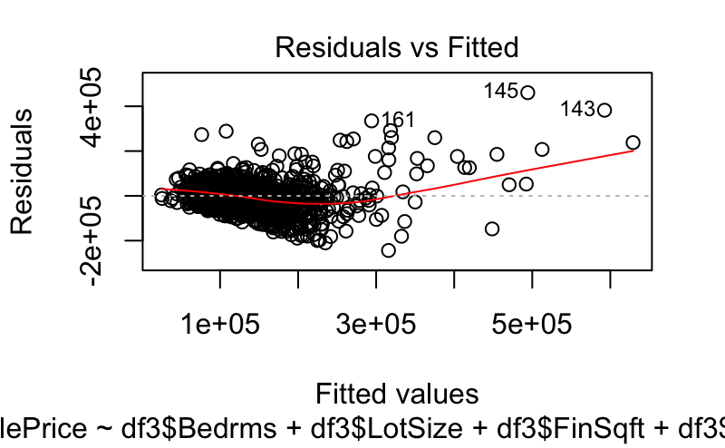

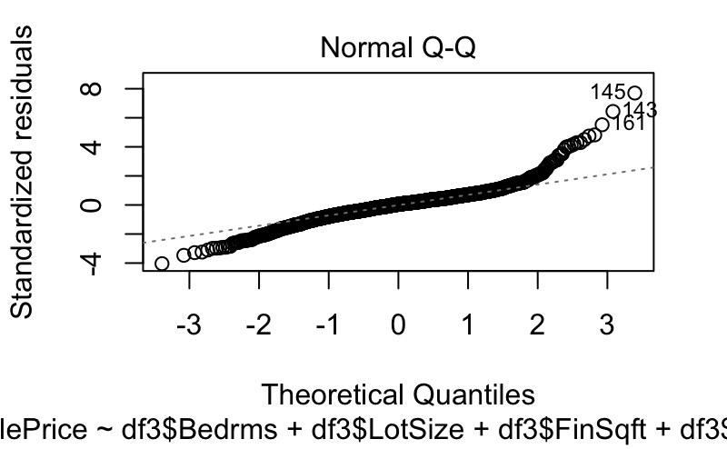

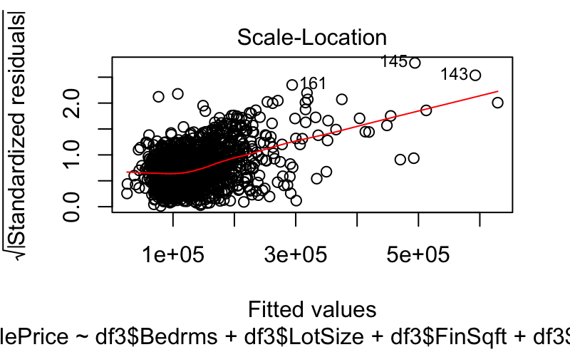

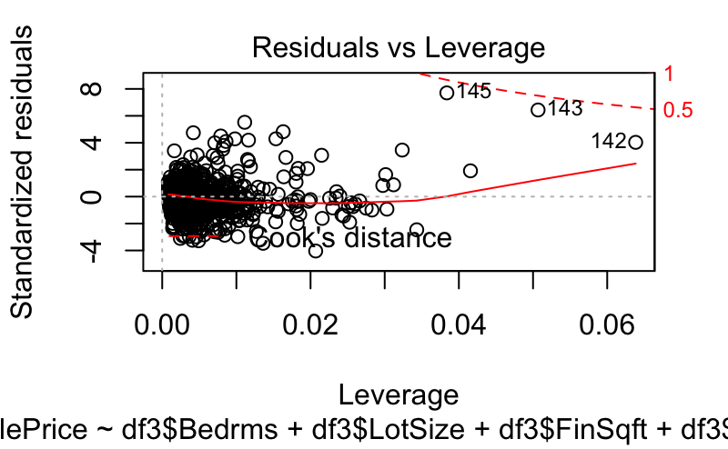

```r
plot(m1)
```

```r
result1 <- anova(m1)
r2_Bedrms <- (result1$`Sum Sq`[1])/(sum(result1$`Sum Sq`))
VIF_Bedrms <- 1/(1-r2_Bedrms)
r2_LotSize <-(result1$`Sum Sq`[2])/(sum(result1$`Sum Sq`))
VIF_LotSize <- 1/(1-r2_LotSize)
r2_FinSqft <-(result1$`Sum Sq`[3])/(sum(result1$`Sum Sq`))
VIF_FinSqft <- 1/(1-r2_FinSqft)
r2_Age <-(result1$`Sum Sq`[4])/(sum(result1$`Sum Sq`))
VIF_Age <- 1/(1-r2_Age)
r2_Baths <-(result1$`Sum Sq`[5])/(sum(result1$`Sum Sq`))
VIF_Baths <- 1/(1-r2_Baths)
c2 <- rbind(VIF_Bedrms,VIF_LotSize,VIF_FinSqft,VIF_Age,VIF_Baths)
c1 <- rbind("1","2","3","4","5")
Vif <- cbind(c1,c2)
colnames(Vif) <- c("Number","VIF")
library(knitr)
kable(Vif)
```

|  | Number | VIF |
| --- | --- | --- |
| VIF_Bedrms | 1 | 1.08528884581453 |
| VIF_LotSize | 2 | 1.04734728258682 |
| VIF_FinSqft | 3 | 1.53021787867496 |
| VIF_Age | 4 | 1.00263092819862 |
| VIF_Baths | 5 | 1.01397861698636 |

```r
# Multicollinearity will increase the percentage of the model to explain the variation in the outcome compared to the linear regression
# The slope of age is not significant
```

### Question 3(b)

Attempt to improve the regression equation found in (a). Justify your decisions in constructing and carrying out the analysis.

```r
reduced1 <- step(object = m1,direction = "backward")
```

```
Start:  AIC=31937.3
df3$SalePrice ~ df3$Bedrms + df3$LotSize + df3$FinSqft + df3$Age +
    df3$Baths

              Df  Sum of Sq        RSS
<none>                      5.3669e+12
- df3$Age      1 1.0901e+10 5.3778e+12
- df3$LotSize  1 1.1485e+11 5.4817e+12
- df3$Baths    1 1.4414e+11 5.5110e+12
- df3$Bedrms   1 5.4651e+11 5.9134e+12
- df3$FinSqft  1 1.8347e+12 7.2016e+12
                AIC
<none>        31937
- df3$Age     31938
- df3$LotSize 31966
- df3$Baths   31974
- df3$Bedrms  32076
- df3$FinSqft 32361
```

```r
summary(reduced1)
```

```
Call:
lm(formula = df3$SalePrice ~ df3$Bedrms + df3$LotSize + df3$FinSqft +
    df3$Age + df3$Baths)

Residuals:
    Min      1Q  Median      3Q     Max
-243841  -29791    2824   28372  460759

Coefficients:
              Estimate Std. Error t value
(Intercept)  2.624e+04  9.420e+03   2.786
df3$Bedrms  -2.876e+04  2.372e+03 -12.122
df3$LotSize  3.580e+00  6.442e-01   5.557
df3$FinSqft  1.007e+02  4.535e+00  22.210
df3$Age     -1.306e+02  7.629e+01  -1.712
df3$Baths    2.302e+04  3.698e+03   6.225
            Pr(>|t|)
(Intercept)  0.00541 **
df3$Bedrms   < 2e-16 ***
df3$LotSize 3.26e-08 ***
df3$FinSqft  < 2e-16 ***
df3$Age      0.08711 .
df3$Baths   6.29e-10 ***
---
Signif. codes:
  0 ‘***’ 0.001 ‘**’ 0.01 ‘*’ 0.05 ‘.’
  0.1 ‘ ’ 1

Residual standard error: 60990 on 1443 degrees of freedom
Multiple R-squared:  0.4867,    Adjusted R-squared:  0.4849
F-statistic: 273.6 on 5 and 1443 DF,  p-value: < 2.2e-16
```

```r
# the slope of the age is not significant
# salePrice ~ 26240 + (-28760)*Bedrms + 3.58*Lotsize + 100.7*FinSqft + 23020*Baths
```